# About

### Predictive Ecology Lab Group

We are located in Victoria, British Columbia, Canada, at the Pacific Forestry Centre. Several lab members are students through Université Laval and are based out of Québec City.

#### Eliot McIntire

**Research Scientist, Natural Resources Canada**  
**Adjunct Professor, University of British Columbia & Université Laval**

My research interests lie in applied ecology, conservation and forecasting of a broad array of ecosystems and species. Specifically, I am interested in using modern quantitative techniques to understand the natural complexity of ecosystems, and ultimately, to allow forecasting of organisms and ecosystem processes. I use a variety of quantitative techniques, including Hierarchical Bayes, Spatial Analysis, Landscape Simulation Modeling, Structural Equation Modeling, and Non-Linear Models to achieve the best ecological inference from ecological data. Through each of the systems I study, I strive to understand the ecological processes and to test this understanding by forecasting.

[Predictive Ecology Blog](https://predictiveecology.org/) [Predictive Ecology on GitHub](https://github.com/PredictiveEcology) [SpaDES](https://spades.predictiveecology.org)

### Current Personel

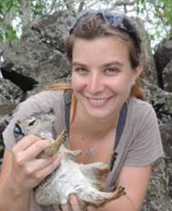

[Dr. Tatiane Micheletti](https://github.com/tati-micheletti/) (Postdoctoral Fellow 2018-) Tati is our “integrator”, asking questions about managing land in Canada when there are multiple, conflicting management pressures. She has been specializing in SpaDES model development, bird and caribou forecasting, protected areas optimization, and tradeoffs/synergies across disciplines.

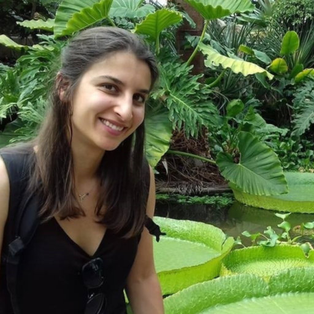

[Dr. Ceres Barros](https://ceresbarros.wordpress.com/) (Postdoctoral Fellow 2018-) (on Parental Leave until 2021)

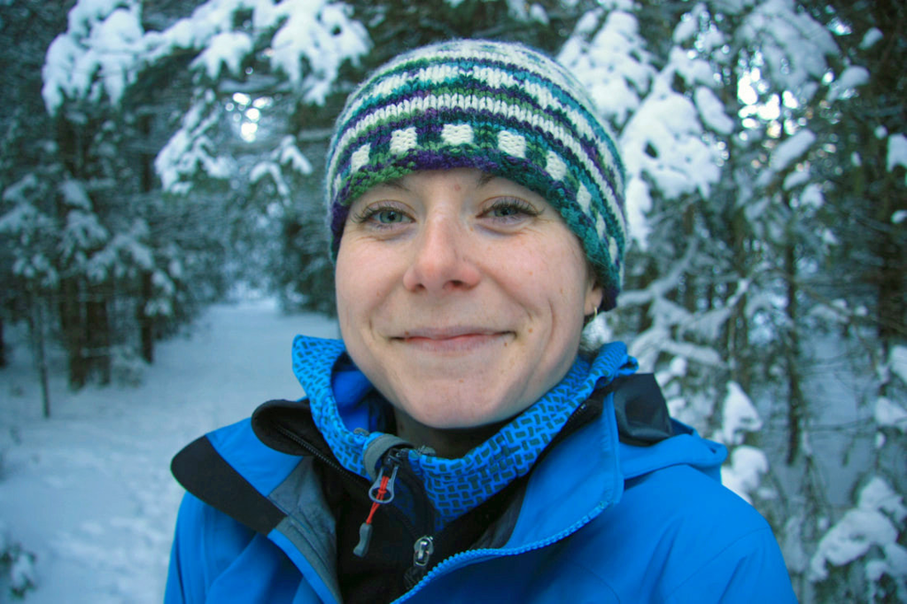

[Dr. Frances Stewart](http://www.stewartresearch.ca/) (Postdoctoral Fellow 2019-2020 on Parental Leave until 2021)

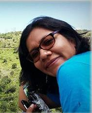

[Ana Raymundo](https://borealbirds.ualberta.ca/2019/07/11/ana-raymundo/) (PhD Student 2018-) Ana is working on questions related to forestry and birds across Canada. A student at Laval University, she is currently in Victoria learning the SpaDES ecosystem.

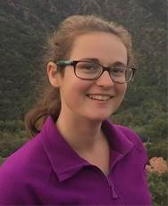

[Isolde Lane Shaw](https://borealbirds.ualberta.ca/2019/07/11/isolde-lane-shaw/) (PhD Student 2018-) (Postdoctoral Fellow 2018-)

### Former Personel

Alex Chubaty (Postdoctoral Fellow 2017)

[Alana Clason](https://bvcentre.ca/index.php/people/bio/alana_clason1) (PhD 2018)

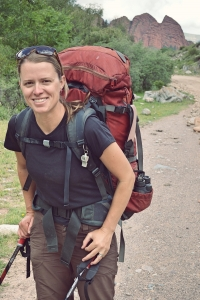

[Sarah Bauduin](https://www.sarahbauduin.fr/) (PhD 2018)

[figure not shown]

[Sebastien Renard](https://www.researchgate.net/profile/Sebastien_Renard2)

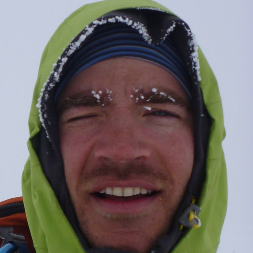

[Jean Marchal](https://www.wavx.ca/) (PhD 2017)

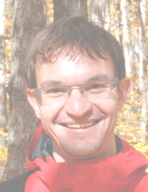

[Yong Luo](https://sites.google.com/a/lakeheadu.ca/yong-luo/home) (Postdoctoral Fellow 2017)

[Josh Nowak](https://www.speedgoat.io/story/) (PhD 2015)

[figure not shown]

- Greg Zhang (BSc Coop 2015)
- [Émilie Tarroux](https://chaireafd.uqat.ca/chercheurs/PageIndividus_f.asp?IdCollaboration=50) (Post Doctoral Fellow 2015)
- [Julien Beguin](https://www.cef-cfr.ca/index.php?n=Membres.JulienBeguin) (PhD 2013)
- [Julia Chacon Labella](https://www.researchgate.net/profile/Julia_Chacon-Labella/) (PhD - Visiting 2013)
- [Pierre Racine](https://www.cef-cfr.ca/index.php?n=Membres.PierreRacine) (Research Professional 2013)
- [Ghislain Rompré](https://www.cef-cfr.ca/index.php?n=Membres.GhislainRompre) (Post Doctoral Fellow 2009)
- [Pamela Garcia-Cournoyer](https://www.cef-cfr.ca/index.php?n=Membres.PamelaGarciaCournoyer) (MSc 2010)
- [Émilie Allard](https://www.cef-cfr.ca/index.php?n=Membres.EmilieAllard) (MSc 2009)
- [Melanie Smith](https://ak.audubon.org/melanie-smith-science-director) (MSc 2008)
- Céline Macabiau (PhD 2009)
- Motoshi Honda (MSc 2008)
- [Alex Fajardo](https://sites.google.com/site/alexfajardosite/) (Post Doctoral Fellow 2006)
- Trevor Schiavone (Coop student 2015 `SpaDES` GUI development.)
- Brandon Leech (Coop student 2015`SpaDES` GUI development)